### Import libraries

```r
library(readr)
library(tidyverse)
```

```r
library(ggplot2)
library(broom)
library(stats)
```

### Read the data

Reading csv with data about cost of living.

More detailed information about dataset: https://www.kaggle.com/datasets/mvieira101/global-cost-of-living

```r
data <- read_csv("cost-of-living.csv")
```

```
## ──────────────────────────────────────────────────────── Delimiter: "," chr
## (2): city, country dbl (57): ...1, x1, x2, x3, x4, x5, x6, x7, x8, x9, x10,
## x11, x12, x13, x14,...
```

### Structure of the data

x1 - x55 are observed values for some city.

You can check what particular number means on provided link.

The most important parameter for our research is x54 (average monthly salary)

We want to check whether dependency between salary and some prices is linear.

Also we want to compare how fast some parameters grow comparing to salary growth.

```r
head(data)
```

```
## # A tibble: 6 × 59
##    ...1 city     country      x1    x2    x3    x4    x5    x6    x7    x8    x9
##   <dbl> <chr>    <chr>     <dbl> <dbl> <dbl> <dbl> <dbl> <dbl> <dbl> <dbl> <dbl>
## 1     0 Delhi    India      4.9   22.0  4.28  1.84  3.67  1.78  0.48  0.19  0.73
## 2     1 Shanghai China      5.59  40.5  5.59  1.12  4.19  3.96  0.52  0.32  2.68
## 3     2 Jakarta  Indonesia  2.54  22.2  3.5   2.02  3.18  2.19  0.59  0.27  1.28
## 4     3 Manila   Philippi…  3.54  27.4  3.54  1.24  1.9   2.91  0.93  0.51  1.63
## 5     4 Seoul    South Ko…  7.16  52.8  6.03  3.02  4.52  3.86  1.46  0.78  2.13
## 6     5 Bangkok  Thailand   2.6   28.1  5.62  2.25  4.21  2.06  0.5   0.26  1.61
## # … with 47 more variables: x10 <dbl>, x11 <dbl>, x12 <dbl>, x13 <dbl>,
## #   x14 <dbl>, x15 <dbl>, x16 <dbl>, x17 <dbl>, x18 <dbl>, x19 <dbl>,
## #   x20 <dbl>, x21 <dbl>, x22 <dbl>, x23 <dbl>, x24 <dbl>, x25 <dbl>,
## #   x26 <dbl>, x27 <dbl>, x28 <dbl>, x29 <dbl>, x30 <dbl>, x31 <dbl>,
## #   x32 <dbl>, x33 <dbl>, x34 <dbl>, x35 <dbl>, x36 <dbl>, x37 <dbl>,
## #   x38 <dbl>, x39 <dbl>, x40 <dbl>, x41 <dbl>, x42 <dbl>, x43 <dbl>,
## #   x44 <dbl>, x45 <dbl>, x46 <dbl>, x47 <dbl>, x48 <dbl>, x49 <dbl>, …
```

### Plotting data

```r
plotting <- function(salary, param) {
  hist(salary, col="darkred", border="white")
  hist(param, col="darkred", border="white")
}
```

### Mean value

```r
means <- function(param) {
  return(mean(param))
}
```

### Data Grouping

For our research we group our data the following way:

Sort the data by average salary, and then divide them by groups.

We use this approach mainly to avoid outliers and make the data more generalized.

```r
group_by <- function(data, n) {
  x <- map_dbl(data, 1)
  y <- map_dbl(data, 2)
  sorted_x <- sort(x)
  sorted_y <- y[order(x)]
  data <- map2(sorted_x, sorted_y, ~ c(.x, .y))
  count <- 0
  grouped_list <- list()
  salary_sum <- 0
  gasonile_sum <- 0
  for(tuple in data) {
    count <- count + 1
    salary_sum <- salary_sum + tuple[[1]]
    gasonile_sum <- gasonile_sum + tuple[[2]]
    if (count == n) {
      grouped_list[[length(grouped_list) + 1]] <- list(salary_sum / n, gasonile_sum / n)
      count <- 0
      salary_sum <- 0
      gasonile_sum <- 0
    }
  }
  grouped_list[[length(grouped_list) + 1]] <- list(salary_sum / count, gasonile_sum / count)
  return(grouped_list)
}
```

### Plotting linear model

```r
lm_plotting <- function(lm) {
  plot(x, y, pch=16, col="blue")
  abline(lm, col = "red")
}
```

#### Firstly we want to check how gasoline price depends on salary

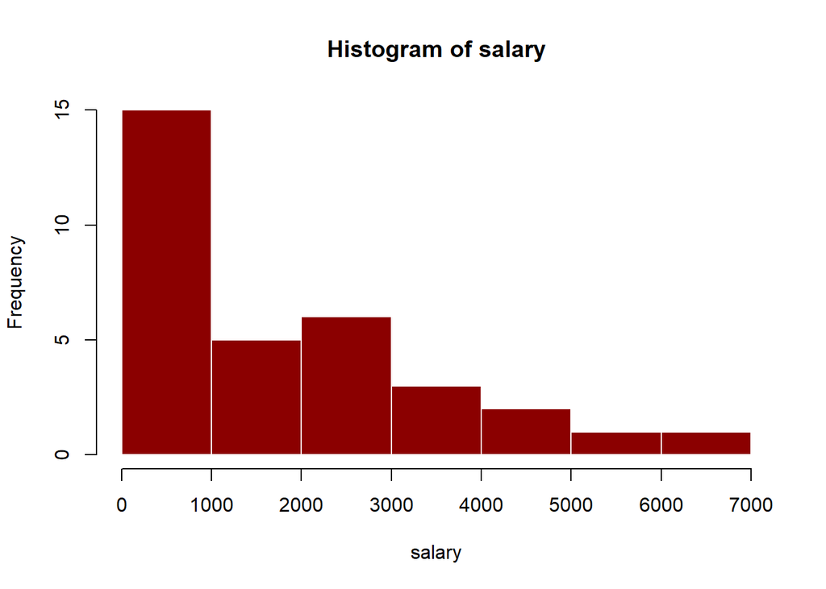

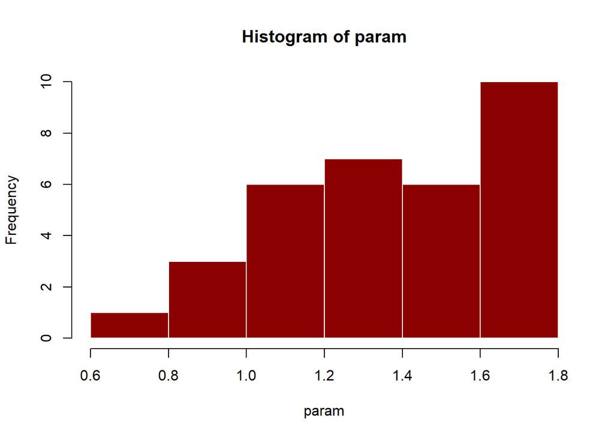

```r
new_data <- data[! is.na(data$x54) & ! is.na(data$x33), ]
merge_list <- map2(new_data$x54, new_data$x33, ~ c(.x, .y))
grouped_list <- group_by(merge_list, 100)

x <- map_dbl(grouped_list, 1)
y <- map_dbl(grouped_list, 2)
plotting(x, y)
```

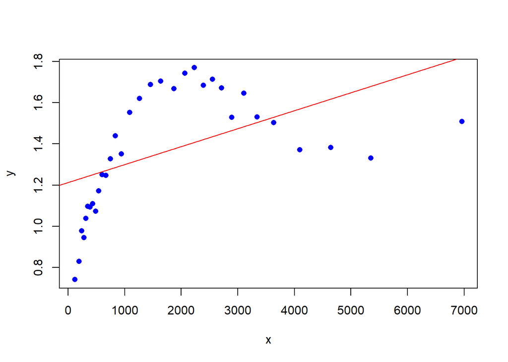

```r
linear_model <- lm(y ~ x)
lm_plotting(linear_model)
```

#### We can see that dependency is not linear

If we look at our data plot, we can see, that after some point, greater salary leads to even lower gasoline price.

So, the dependency between salary and gasoline price is not linear.

It can be explained by the fact, that countries, who have own oil and gasoline are usually rich.

So, salary is getting higher, while gasoline price stays the same, or even lower.

In our research we are interested only in linear dependencies.

So, we will ignore parameters, which are do not fit well to linear model.

#### Let’s try to check other dependencies(salary ~ Apartment in City centre and salary ~ primary school)

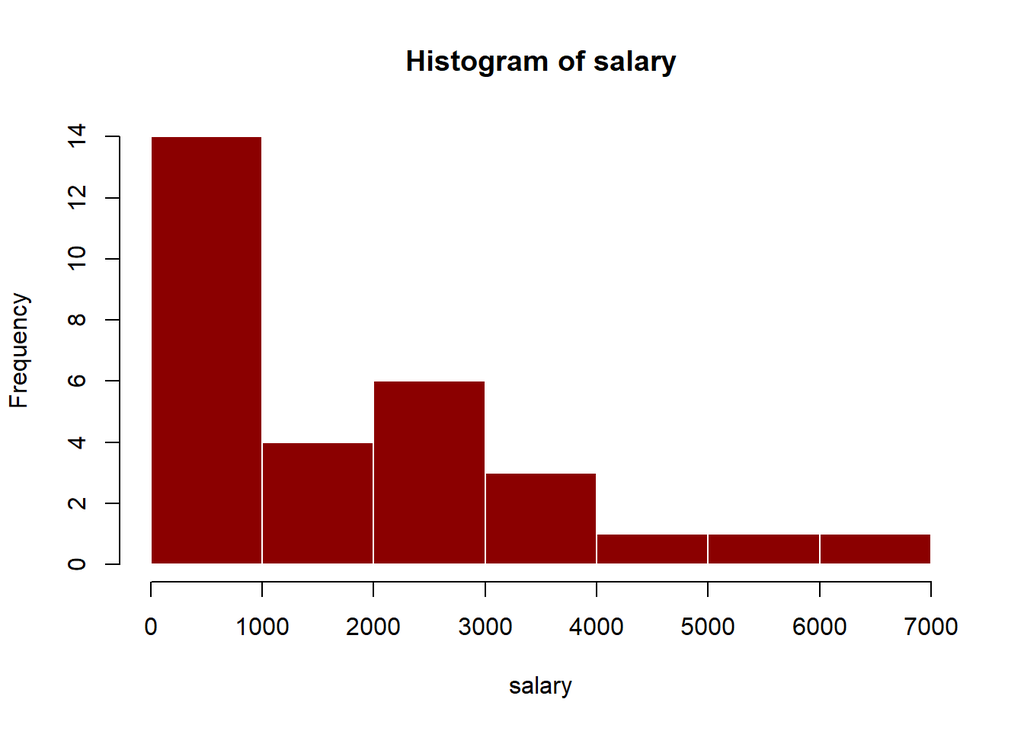

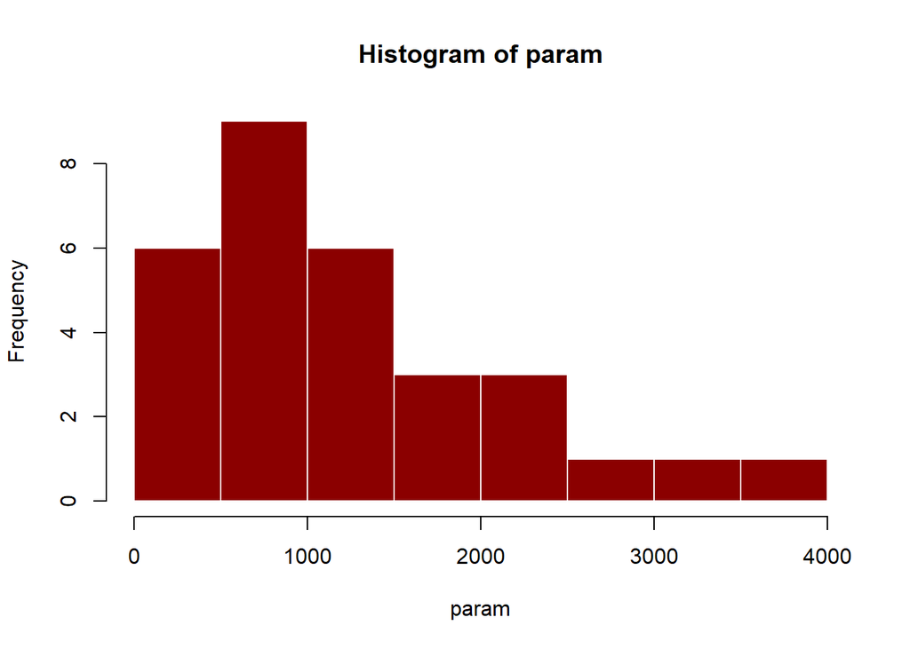

```r
new_data <- data[! is.na(data$x54) & ! is.na(data$x50), ]
merge_list <- map2(new_data$x54, new_data$x50, ~ c(.x, .y))
grouped_list <- group_by(merge_list, 100)

x <- map_dbl(grouped_list, 1)
y <- map_dbl(grouped_list, 2)
plotting(x, y)
```

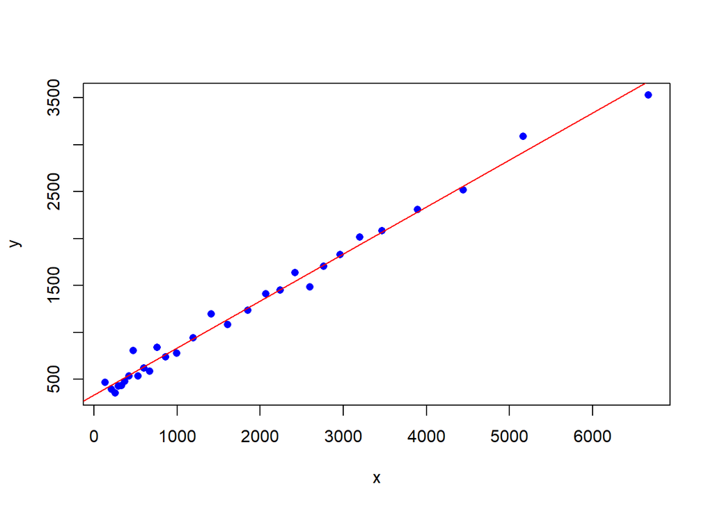

```r
linear_model1 <- lm(y ~ x)
lm_plotting(linear_model1)
```

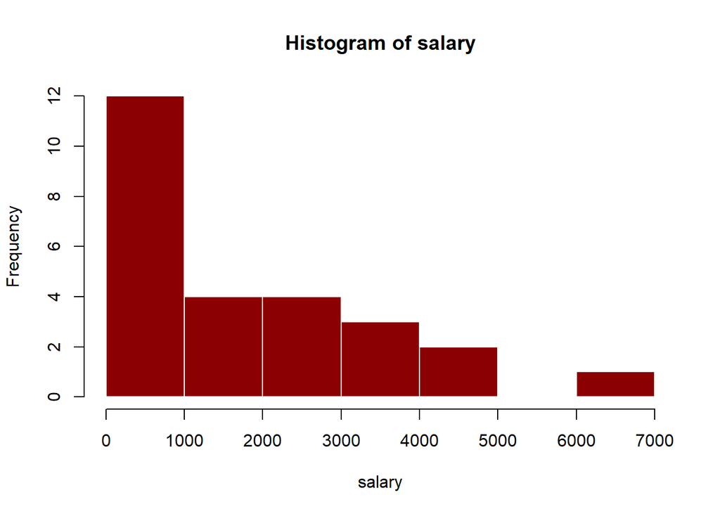

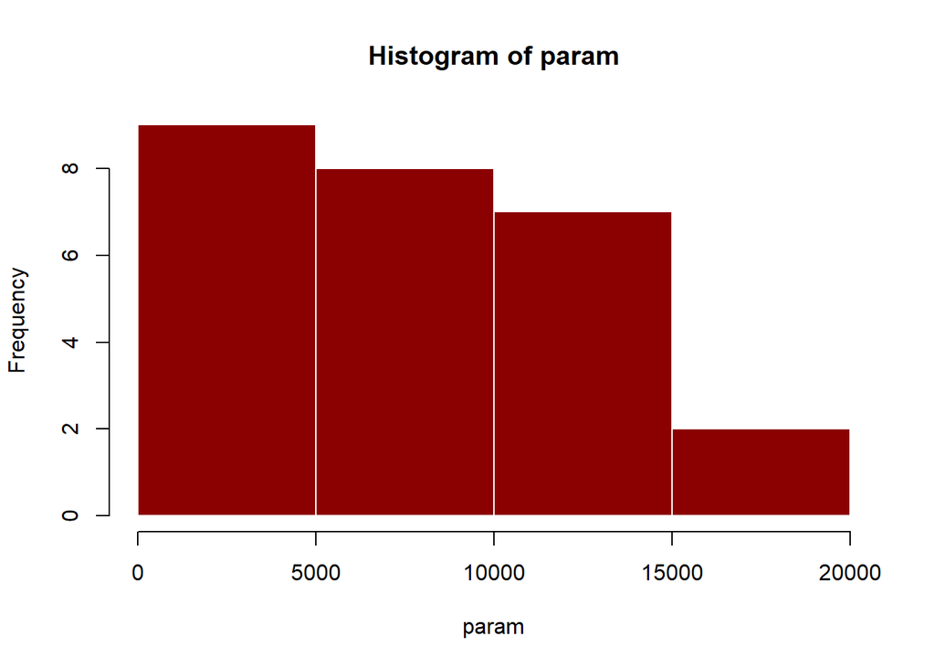

```r
new_data <- data[! is.na(data$x54) & ! is.na(data$x43), ]
merge_list <- map2(new_data$x54, new_data$x43, ~ c(.x, .y))
grouped_list <- group_by(merge_list, 100)

x <- map_dbl(grouped_list, 1)
y <- map_dbl(grouped_list, 2)
plotting(x, y)
```

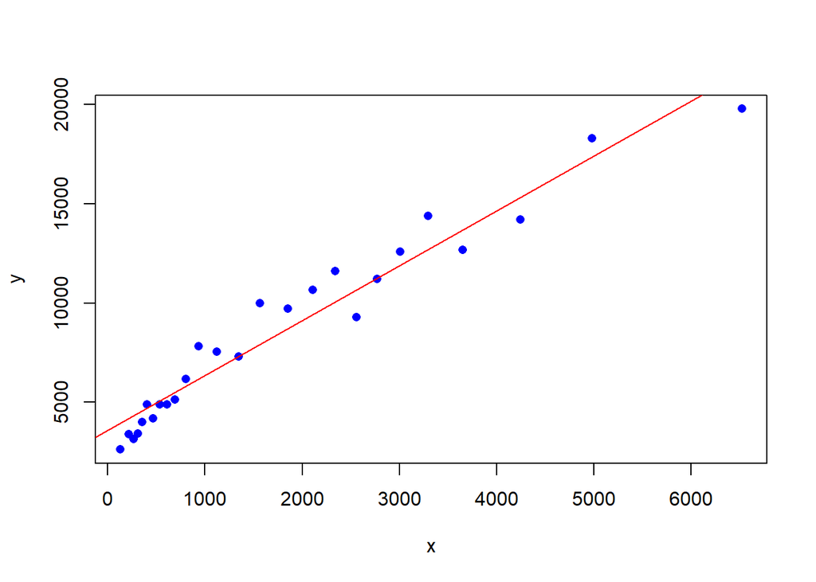

```r
linear_model2 <- lm(y ~ x)
lm_plotting(linear_model2)
```

### We see two linear models with high goodness-of-fit

Their deterministic coefficient is high, so the distribution is linear.

let’s compare their slopes param.

This way we can check how fast some parameter grows according to salary growth.

```r
new_data <- data[! is.na(data$x54) & ! is.na(data$x50), ]
slope1 <- round(means(new_data$x54) / means(new_data$x50) * coef(linear_model1)[2], 2)
new_data <- data[! is.na(data$x54) & ! is.na(data$x43), ]
slope2 <- round(means(new_data$x54) / means(new_data$x43) * coef(linear_model2)[2], 2)
print(slope1)
```

```
##    x
## 0.73
```

```r
print(slope2)
```

```
##    x
## 0.58
```

We see that price of apartments grows faster that price for primary school.

It means that in rich countries apartments are also much-more expensive, while growth in school price is not so significant.

### Table

In this section we build a table, which shows speed of growth of some parameter comparing to salary growth.

This coefficient is obtained from slope coefficient of regression model.

If our model fits bad in linear regression (has low r^2 deterministic coefficient), we print 0.

```r
mtr <- matrix(0, nrow = 53, ncol = 2)
count <- 1
data <- data[! is.na(data$x54), ]
for(col in colnames(data)) {
  if (col != "x54" & col != "data_quality" & col != "city" & col != "country" & col != "...1" & col != "x42") {
    mtr[count, 1] <- col
    new_data <- data[ ! is.na(data[[col]]), ]
    merge_list <- map2(new_data$x54, new_data[[col]], ~ c(.x, .y))
    grouped_list <- group_by(merge_list, 100)
    x <- map_dbl(grouped_list, 1)
    y <- map_dbl(grouped_list, 2)
    linear_model <- lm(y ~ x)
    model_summary <- summary(linear_model)
    r_squared <- model_summary$r.squared
    if (r_squared > .75) {
      mtr[count, 2] <- round(means(x) / means(y) * coef(linear_model)[2], 2)
    }
    count <- count + 1
  }
}
for (i in 1:dim(mtr)[1]) {
    for (j in 1:dim(mtr)[2]) {
        cat(mtr[i, j], " ")
    }
    cat("\n")
}
```

```
## x1  0.51
## x2  0.41
## x3  0.26
## x4  0.47
## x5  0.4
## x6  0.4
## x7  0.43
## x8  0.52
## x9  0
## x10  0.5
## x11  0.48
## x12  0.33
## x13  0.25
## x14  0.45
## x15  0.38
## x16  0.4
## x17  0
## x18  0.4
## x19  0.49
## x20  0.45
## x21  0.42
## x22  0.38
## x23  0.47
## x24  0.28
## x25  0.31
## x26  0.19
## x27  0
## x28  0
## x29  0.54
## x30  0
## x31  0
## x32  0.66
## x33  0
## x34  0
## x35  0
## x36  0
## x37  0
## x38  0
## x39  0
## x40  0
## x41  0.39
## x43  0.58
## x44  0
## x45  0
## x46  0
## x47  0
## x48  0.76
## x49  0.79
## x50  0.73
## x51  0.78
## x52  0.48
## x53  0.54
## x55  0
```

### Result of research

From this table we can see, that a lot of parameters grow not linear.

It shows that simple linear regression is not the best tool to make some researches,

because real-world data usually depends on a lot of parameters and this dependency is non-linear.

However, we can say that apartment price grows the fastest, so people in rich cities have approximately the same possibility to buy them, as people in poor cities.

The slowest grows we get is a price on import beer, which means that beer price almost do not depend on salary level and is quite close in all categories.

What is more, we do not have any parameter which is higher than 1.

It means that prices to all parameters grow slower than salary, so people in rich cities can afford more, because growth in salary is higher than growth in other parameters.